# STA510 - Mandatory Assignment 1

Tommaso Facchin

24 settembre 2026

# 1 Problem 1

## 1.1 d)

```r
a <- 5
n <- 5000

F <- function(x, a) {(3 / 4000) * (10 * (x - a)^2 - (x - a)^3 / 3)}

F_inv <- function(p, a) {
  uniroot(
    function(x) F(x, a) - p,
    lower = a,
    upper = a + 20
  )$root
}

set.seed(42)

u <- runif(n)

wind_speed <- sapply(u, F_inv, a = a)
```

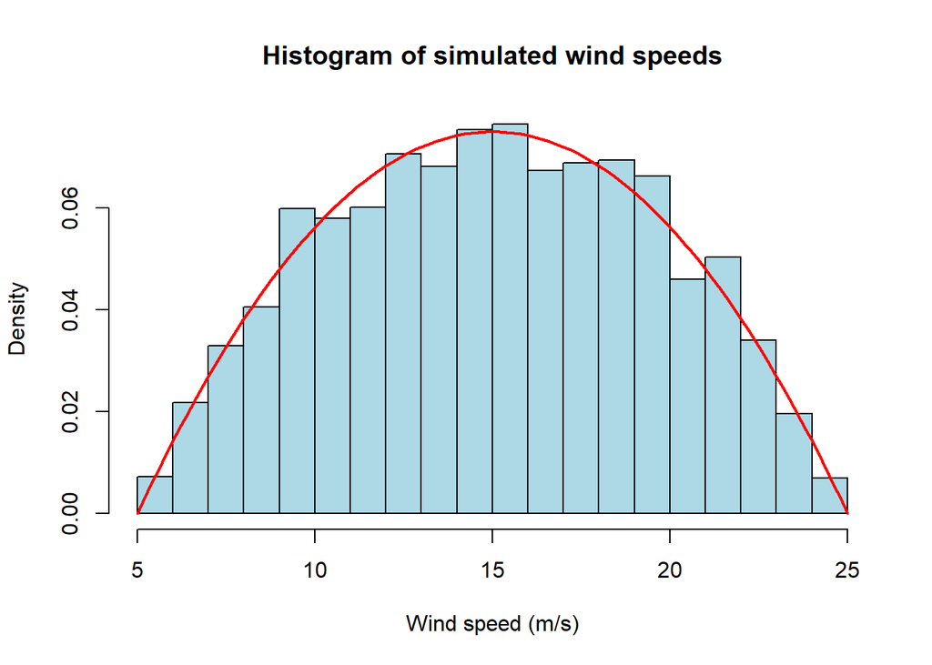

```r
hist(
  wind_speed,
  breaks = "Scott",
  probability = TRUE,
  col = "lightblue",
  main = "Histogram of simulated wind speeds",
  xlab = "Wind speed (m/s)"
)

curve(
  (3 / 4000) * (x - 5) * (25 - x),
  from = 5,
  to = 25,
  add = TRUE,
  col = "red",
  lwd = 2
)
```

The simulated values follow the expected parabolic shape. The density is close to zero near the limits ($5$ m/s and $25$ m/s), and it reaches its maximum around $15$ m/s.

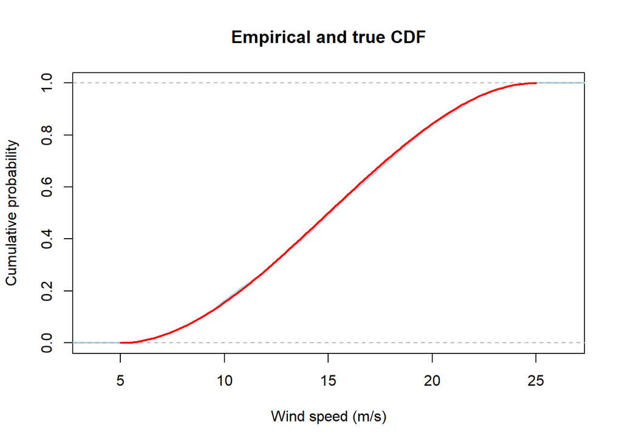

```r
plot(
  ecdf(wind_speed),
  main = "Empirical and true CDF",
  xlab = "Wind speed (m/s)",
  ylab = "Cumulative probability",
  col = "lightblue",
  lwd = 2
)

curve(
  (3 / 4000) * (10 * (x - 5)^2 - (x - 5)^3 / 3),
  from = 5,
  to = 25,
  add = TRUE,
  col = "red",
  lwd = 2
)
```

The empirical CDF is very similar to the true CDF. The empirical CDF is a step function based on the simulated sample, whereas the true CDF is smooth. The two curves are almost overlapping.

## 1.2 e)

### 1.2.1 iii)

The theoretical acceptance rate is

$$\frac{1}{M}
=
\frac{1}{3/2}
=
\boxed{\frac{2}{3}}
\approx0.6667.$$

Approximately 66.67% of the proposed values are expected to be accepted.

To generate 5000 accepted samples, the expected number of proposals is

$$\frac{5000}{2/3}
=
\boxed{7500}.$$

## 1.3 f)

```r
a <- 5
n <- 5000
M <- 3 / 2

wind_ar <- numeric(n)
proposed <- 0
i <- 1

while (i <= n) {

  x <- runif(1, min = a, max = a + 20)

  u <- runif(1)

  acceptance_probability <- (
    (3 / 4000) * (x - a) * (a + 20 - x)
  ) / (M * (1 / 20))

  proposed <- proposed + 1

  if (u <= acceptance_probability) {
    wind_ar[i] <- x
    i <- i + 1
  }
}

empirical_rate <- n / proposed
empirical_rate
```

```
## [1] 0.664187
```

### 1.3.1 i)

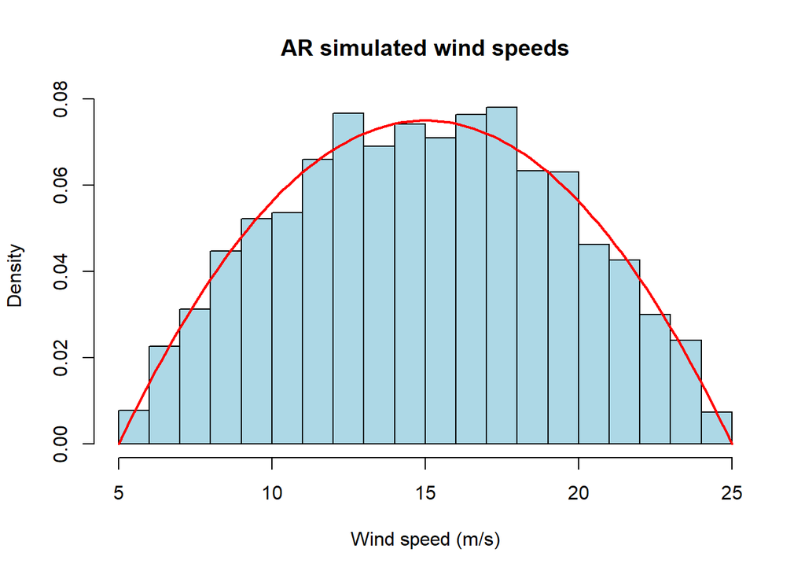

```r
hist(
  wind_ar,
  breaks = "Scott",
  probability = TRUE,
  col = "lightblue",
  main = "AR simulated wind speeds",
  xlab = "Wind speed (m/s)",
  ylab = "Density"
)

curve(
  (3 / 4000) * (x - 5) * (25 - x),
  from = 5,
  to = 25,
  add = TRUE,
  col = "red",
  lwd = 2
)
```

The histogram of the Acceptance-Rejection samples follows the true density well. The simulated values have the expected parabolic shape. Small differences are due to random sampling variation.

### 1.3.2 ii)

The empirical acceptance rate was 0.6642, which is close to the theoretical acceptance rate

$$\frac{1}{M}
\approx0.6667.$$

The small difference is due to random variation in the simulation.

### 1.3.3 iii)

The inverse transform method is preferable when $F^{-1}$ is available or canbe computed efficiently, since every generated uniform value produces one sample. The Acceptance-Rejection method is preferable when the inverse CDF is difficult to obtain but a good proposal distribution is available. Here, AR is reasonably efficient because its theoretical acceptance rate is $2/3$.